# Outlier detection and statistics

# Outlier detection and statistics

```r
##########################################################
## Question 1: VIX Regression Model
##########################################################
#install.packages("zoo")
#install.packages("xts")
#install.packages("utils")
#install.packages("tseries")
library(tseries)
library(utils)
library(zoo)
library(xts)
library(readr)
require(quantmod)
```

```r
require(graphics)
require(timeSeries)
require(xts)
require(car)
require(MLmetrics)
```

Q1. Loading CSV file into “R” and using Data Frames

```r
## Import data
#setwd("~/Desktop/UBS")
data <- read_csv("data.csv")
Vix_data<-data.frame(t(data[,-1]))
colnames(Vix_data)<-c("Eq_Ind1","Eq_Ind2","VIX","LIBOR")
rownames(Vix_data)<- c(colnames(data)[-1])

### Removing NA observations - results in quarterly data
Vix_data_TS_Qtrly<-na.omit(Vix_data)
```

Q2.Outlier Detection:

Outlier detection plays a crucial role in data analysis, in that outliers and influential points are distant from other points and tend to impact the model accuracy. Some points are potential outliers Outliers play a very significant part of any data analysis/cleaning steps. The presence of outliers can very much impact the final results of the regression model as they tend to pull the estimates towards themselves and hence the regression deviates from its task of fitting the best model. Some points are potential outliers and other are influential points. Influential points are those observations whose presence/absence can alter the regression result on a great scale. Usually, modellers try to identify(if any) outliers at the early stages of data cleaning and models are built in both the cases with and without these outliers to gauge the importance of these outliers and to further justify on the authenticity of the observation actually being an outlier or has a finite chance of occurence.

Simple Outlier detection can be done by the Help of Boxplots, Scatter plots, Quantile Plot, Checking the Distance from mean.

As a start, identifying observations which are 3-Std.Dev away from the mean might be a good start. It can help to assess the overall feel of the data and how the distribution looks like. Observations outside the 3-Std.Dev deviations definitely raises some concern as these are highly unusual and are very unlikely to occur.

```r
attach(Vix_data_TS_Qtrly)
### STD Deviation Approach
# calculate summary statistics
find_outlier_obs<-function(var1){
  series1<-var1
  data_mean<-mean(series1)
  data_std <-sd(series1)
  # identify outliers
  cut_off = data_std * 3
  lower= data_mean - cut_off
  upper <-data_mean + cut_off
  obs_index<-which(series1<lower| series1 >upper)
  obs_value<-series1[obs_index]

  return(list(Obs_Index=obs_index,Value=obs_value))
}

VIX_outlier_obs<-find_outlier_obs(VIX)
Eq_Ind1_outlier_obs<-find_outlier_obs(Eq_Ind1)
Eq_Ind2_outlier_obs<-find_outlier_obs(Eq_Ind2)
LIBOR_outlier_obs<-find_outlier_obs(LIBOR)

## VIX - Appears that there are two Observations which are outside the 3Sigma Distance from the Mean of the series. Upon checking, the two points lie along the Financial distress period of 2008-2011. Hence such high values can be expected during such a heavy economical distress period. Hence these values are kept in the modelling dataset.
VIX_outlier_obs
```

```
## $Obs_Index
## [1] 75 85
##
## $Value
## [1] 44.14 42.96
```

```r
## Equity Index1 - No extreme Observations observed in this series
Eq_Ind1_outlier_obs
```

```
## $Obs_Index
## integer(0)
##
## $Value
## numeric(0)
```

```r
## Equity Index2 - Appears that there is One Observation which are outside the 3Sigma Distance from the Mean of the series
Eq_Ind2_outlier_obs
```

```
## $Obs_Index
## [1] 109
##
## $Value
## [1] 6903.389
```

```r
## Libor - No extreme Observations observed in this series
LIBOR_outlier_obs
```

```
## $Obs_Index
## integer(0)
##
## $Value
## numeric(0)
```

Visualization tools and diagnostic plots are essential in pre-processing of the data. Looking at plots of Boxplots, Scatterplots, and Normal-Quantile plots would help analyse the behavior of each individual series.

Boxplots help in understanding the distributions of the data, look at the range and IQR, quartiles and outliers. Extreme observations outside the whiskers of the Boxplot could be potential outliers.

Scatterplots help in understanding the relationship between two variables or infer the trend in one or more variables. If an observation is distant from the major scatter of data then it might be a potential outlier.

Quantile-Quantile plots are basic diagnostic plots in understanding how the quantiles of the observations deviate from the theoretical normal quantiles.

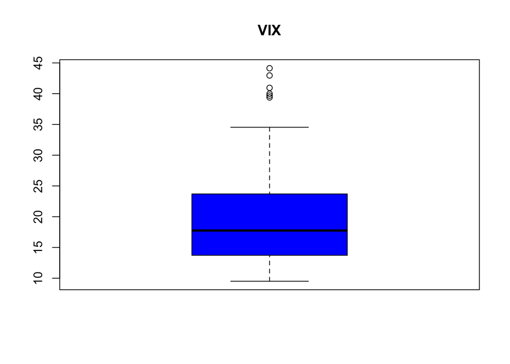

```r
attach(Vix_data_TS_Qtrly)

boxplot(VIX, col = "Blue",main="VIX")
```

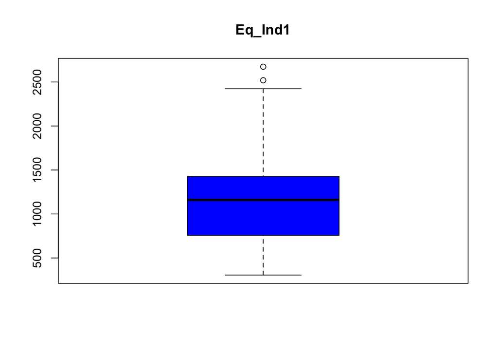

```r
boxplot(Eq_Ind1,col = "Blue",main="Eq_Ind1")
```

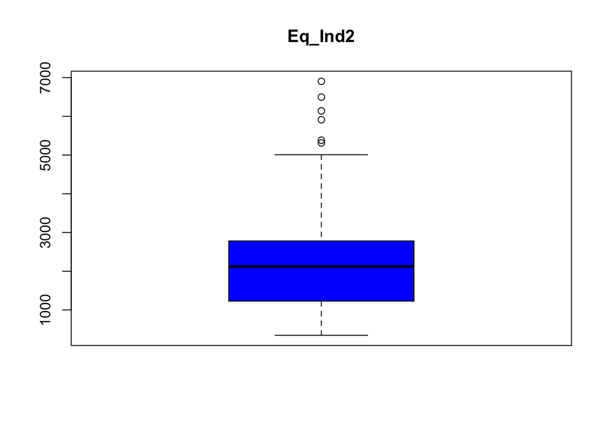

```r
boxplot(Eq_Ind2,col = "Blue",main="Eq_Ind2")
```

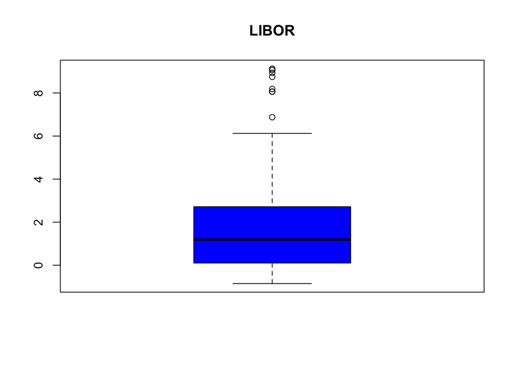

```r
boxplot(LIBOR,col = "Blue",main="LIBOR")
```

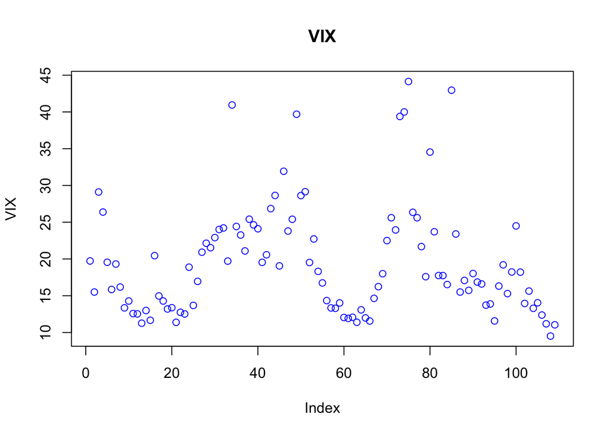

```r
## Scatterplot
plot(VIX, col = "Blue",main="VIX")
```

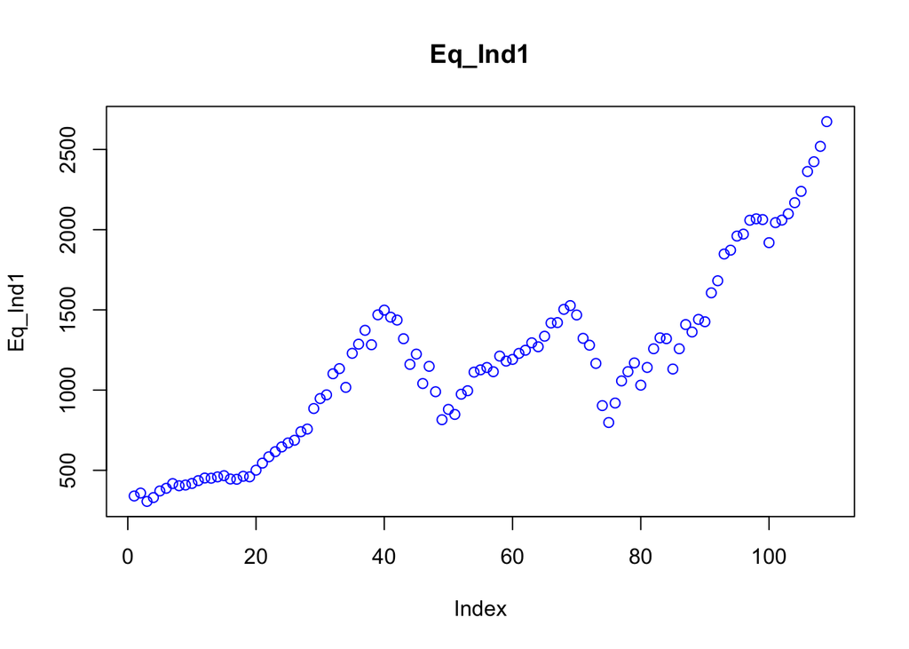

```r
plot(Eq_Ind1,col = "Blue",main="Eq_Ind1")
```

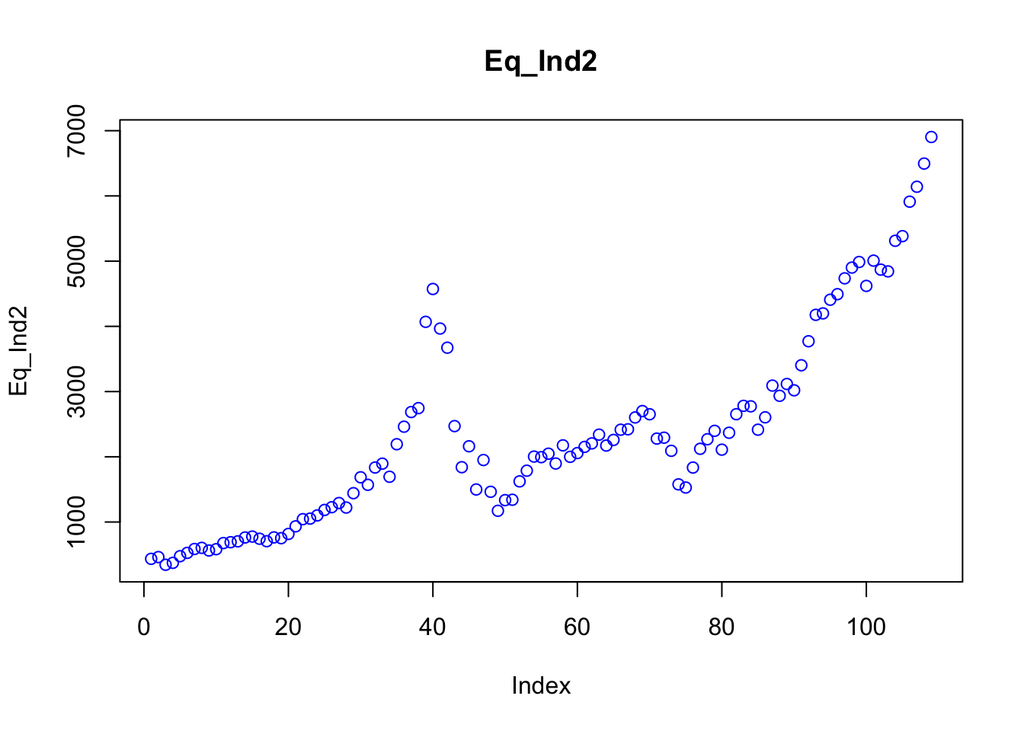

```r
plot(Eq_Ind2,col = "Blue",main="Eq_Ind2")
```

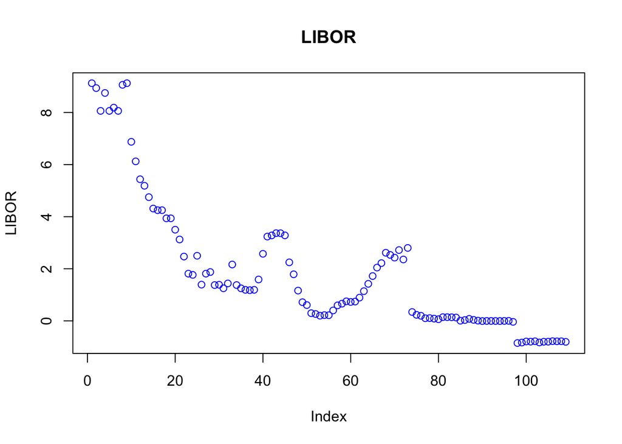

```r
plot(LIBOR,col = "Blue",main="LIBOR")
```

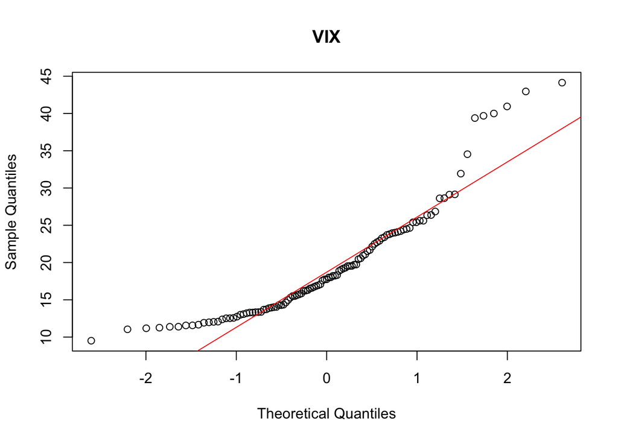

```r
## QQ plots
qqnorm(VIX,main = "VIX");qqline(VIX,col=2)
```

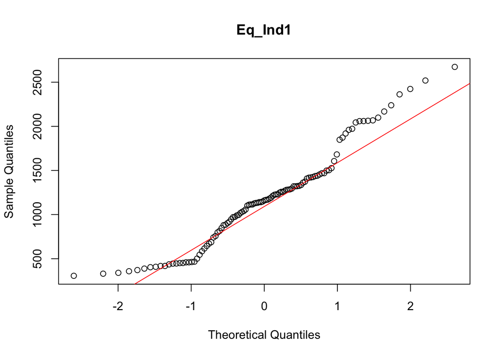

```r
qqnorm(Eq_Ind1,main = "Eq_Ind1");qqline(Eq_Ind1,col=2)
```

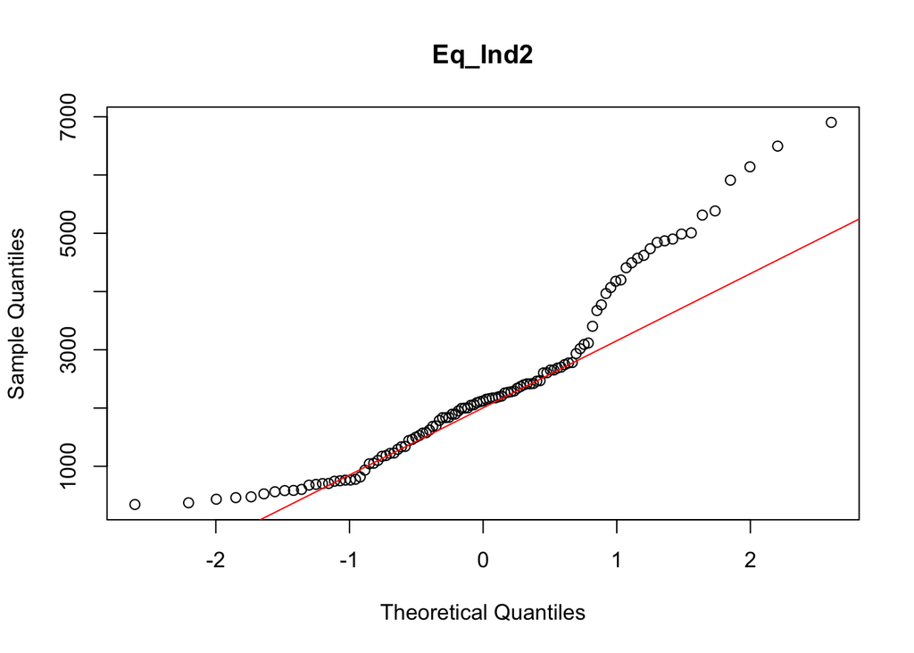

```r
qqnorm(Eq_Ind2,main = "Eq_Ind2");qqline(Eq_Ind2,col=2)
```

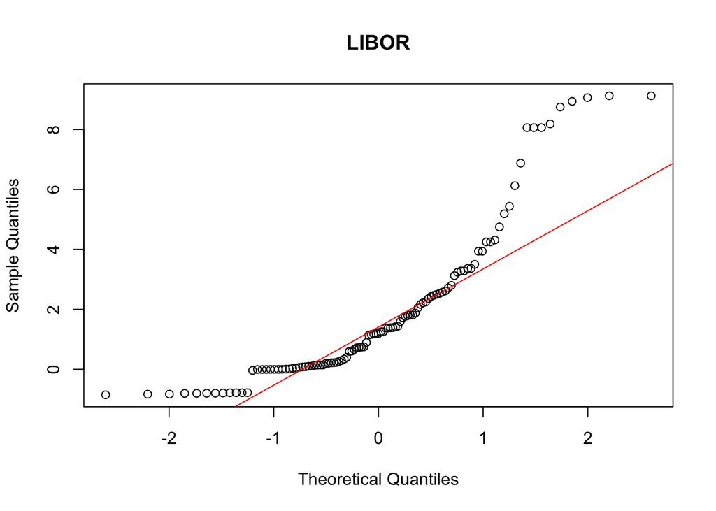

```r
qqnorm(LIBOR,main = "LIBOR");qqline(LIBOR,col=2)
```

It can be inferred from the plots above that there are outliers in the box plots which can be looked into later during model selection and diagnostics. QQplots suggests that the data suffers from extreme tail observations.

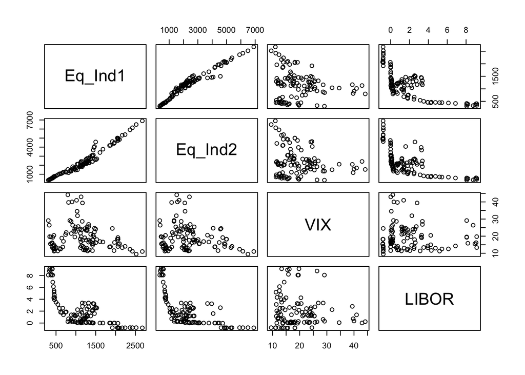

```r
## scatterplot to check for relationship between variables.

plot(Vix_data_TS_Qtrly)
```

```r
## Scatterplot shows that Vix has a decreasing relationship with Equity indexes and shows come correlation. Vix shows very little correlation with libor

cor(Vix_data_TS_Qtrly)
```

```
##            Eq_Ind1    Eq_Ind2         VIX       LIBOR
## Eq_Ind1  1.0000000  0.9744306 -0.16478200 -0.72190386
## Eq_Ind2  0.9744306  1.0000000 -0.18850687 -0.66168760
## VIX     -0.1647820 -0.1885069  1.00000000 -0.05957299
## LIBOR   -0.7219039 -0.6616876 -0.05957299  1.00000000
```

Both Equity indices show high correlation with LIBOR rate and less-to-no correlation with VIX at index levels.

Equity index1 and Equity Index 2 are highly correlated with each other and thus including both the variables in the model would result in the problem of multicollenearity.

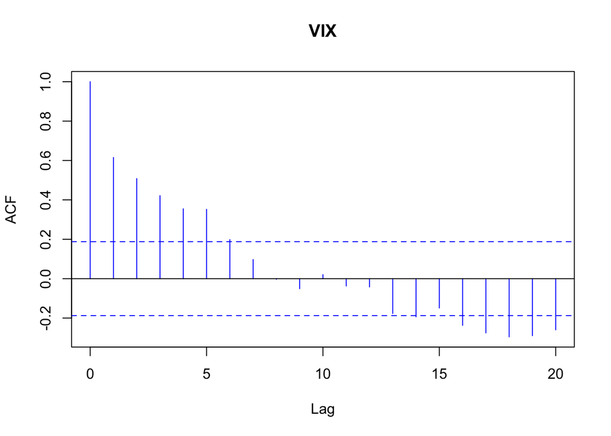

```r
## This may be due to a trend present in the variables at Index level and also the indexes show non-stationary movement
## Scatterplot
acf(VIX, col = "Blue",main="VIX")
```

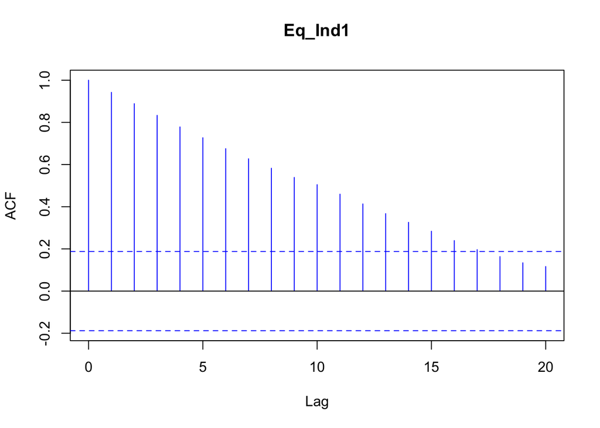

```r
acf(Eq_Ind1,col = "Blue",main="Eq_Ind1")
```

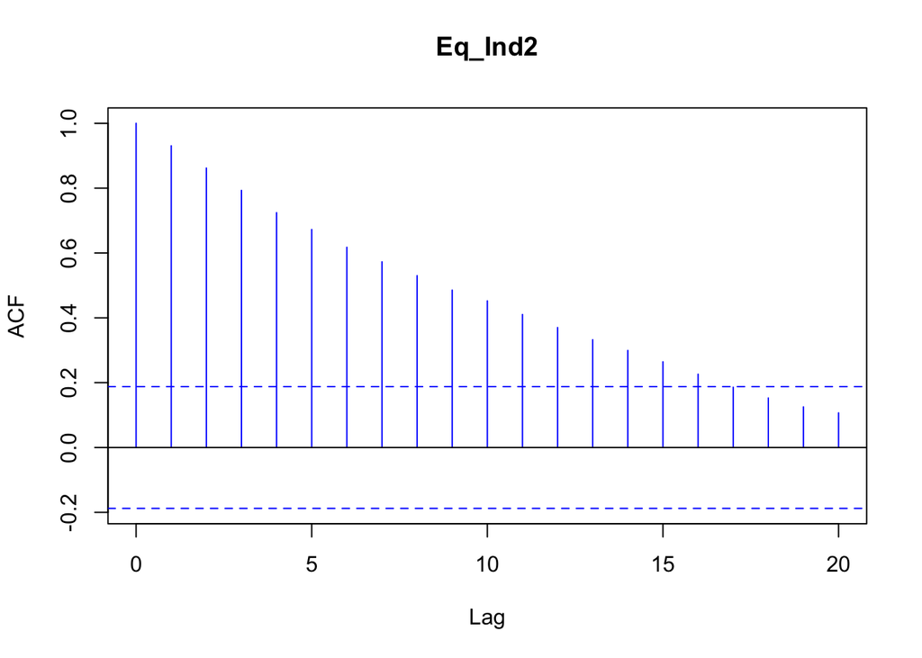

```r
acf(Eq_Ind2,col = "Blue",main="Eq_Ind2")
```

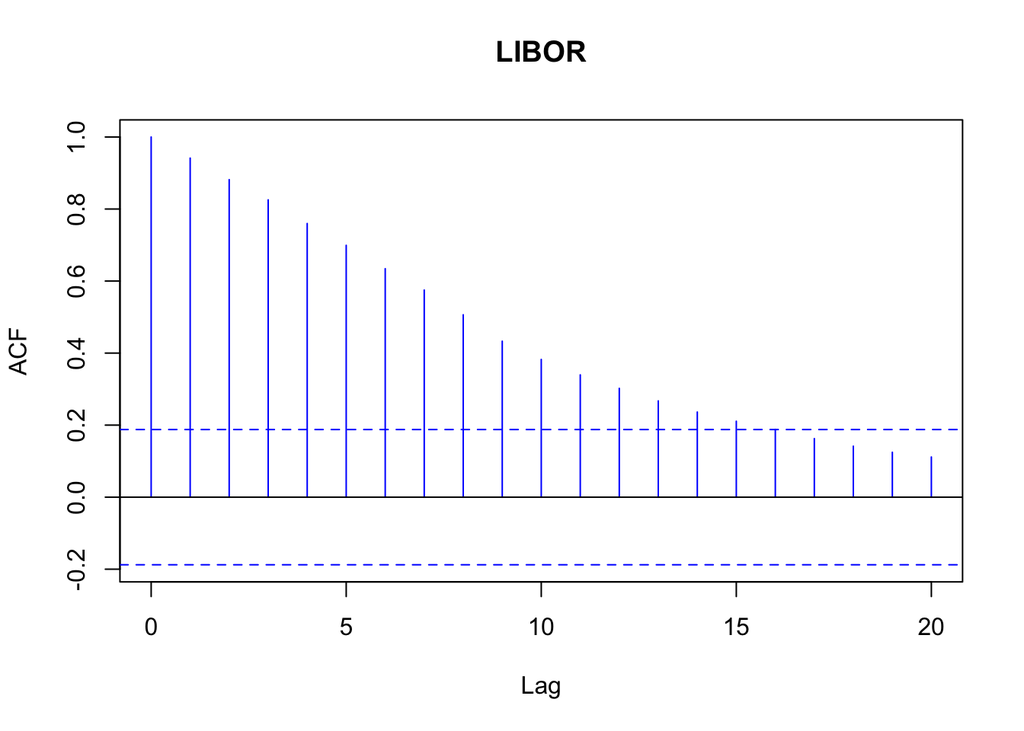

```r
acf(LIBOR,col = "Blue",main="LIBOR")
```

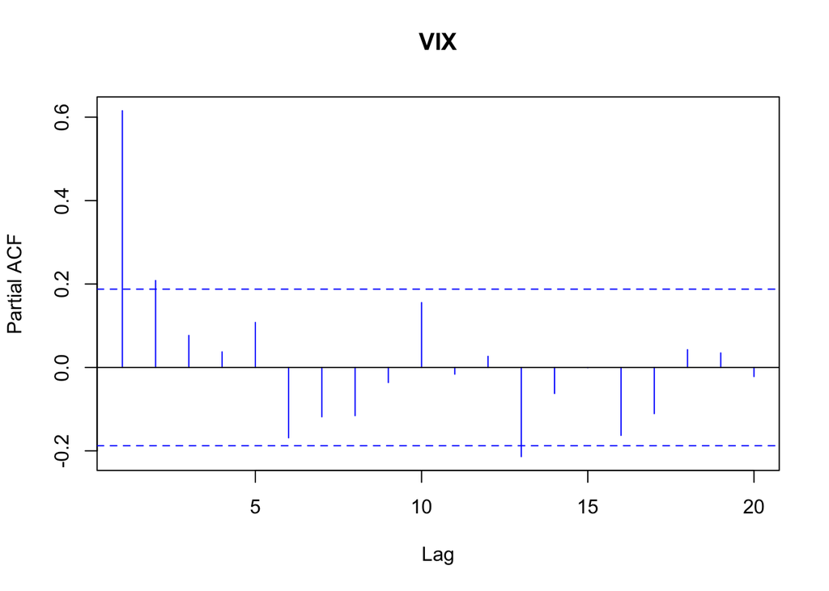

```r
pacf(VIX, col = "Blue",main="VIX")
```

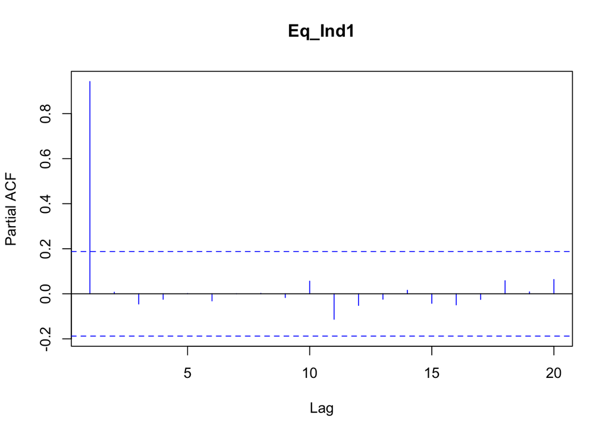

```r
pacf(Eq_Ind1,col = "Blue",main="Eq_Ind1")
```

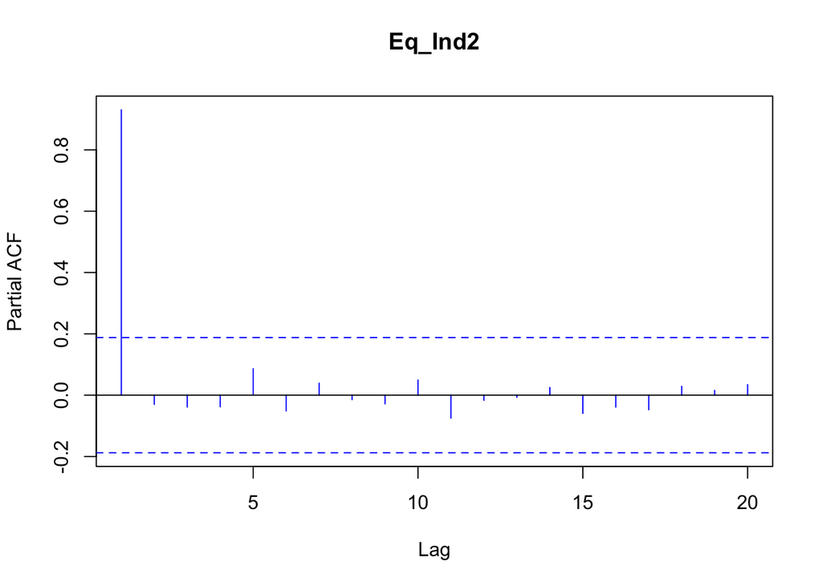

```r
pacf(Eq_Ind2,col = "Blue",main="Eq_Ind2")
```

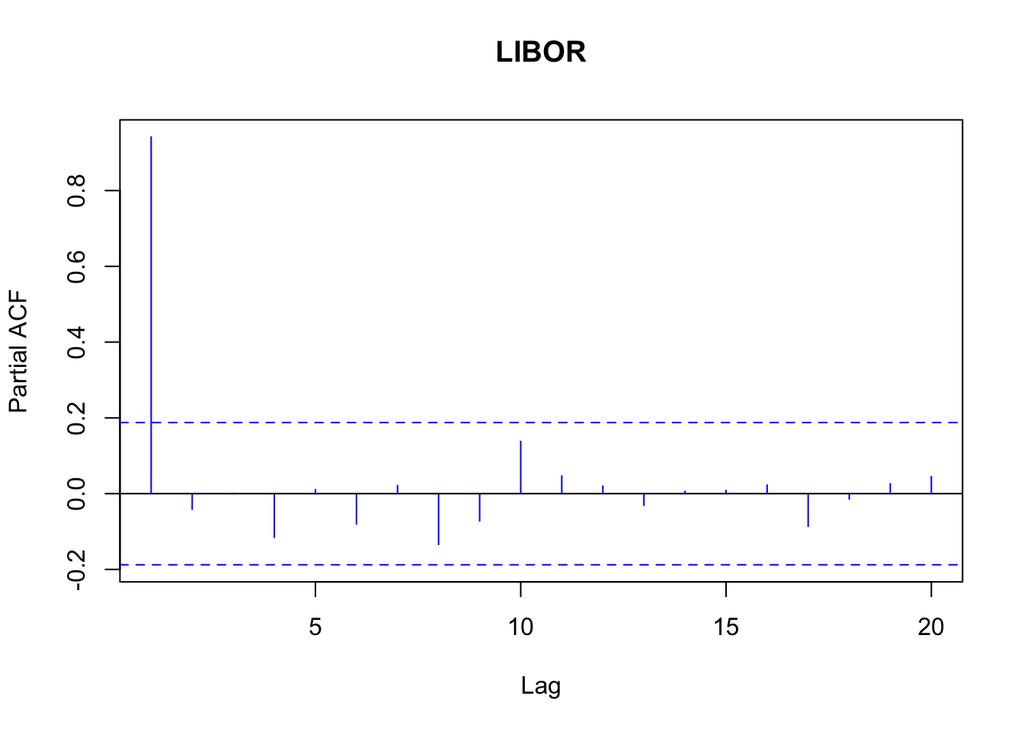

```r
pacf(LIBOR,col = "Blue",main="LIBOR")
```

ACF and PACF plots suggest non-stationary series.

```r
## ACF and PACF plots suggest non-stationary series.

adf.test(VIX)
```

```
##
##  Augmented Dickey-Fuller Test
##
## data:  VIX
## Dickey-Fuller = -2.1521, Lag order = 4, p-value = 0.5136
## alternative hypothesis: stationary
```